# Catalog Comprehensiveness

Oliver Gothe

## Catalog Comeprehensiveness

We are trying to measure catalog comprehensiveness. The only way to truly do this is to scan all items in a store and match against our catalog. However, this is not a feasible solution. The Catalog Ops team is tackling this issue here (Quip: https://instacart.quip.com/1sV0A1jKwVxa). As part of this project they have sampled 4 stores by scanning approximately 1200 codes in each store and then matching the results against our catalog. I believe we can use special requests as an indicator for store comprehesiveness. Specifically, I queried the db for the found rate, special request rate, and percentage of times a special request was replaced with a real item. The results are below:

```r
library(ggplot2)
comp = read.csv("comprehensiveness.csv")
head(comp)
```

```
##                store match_rate sr_rate sr_replaced found_rate
## 1            Rainbow      0.835    0.44        0.47      89.23
## 2       WFM Franklin      0.867    0.34        0.51      88.09
## 3    Costco 10th St.      0.730    0.33        0.40      90.68
## 4 Safeway Market St.      0.631    0.37        0.36      85.73
```

## Plot and Add Linear Regression

Neither found_rate nor sr_rate correlated to match_rate. However, the percentage of special requests replaced by items in the catalog strongly correlated. This results makes sense because if we have a comprehensive catalog it is more likely that a special request item can be found in the store.

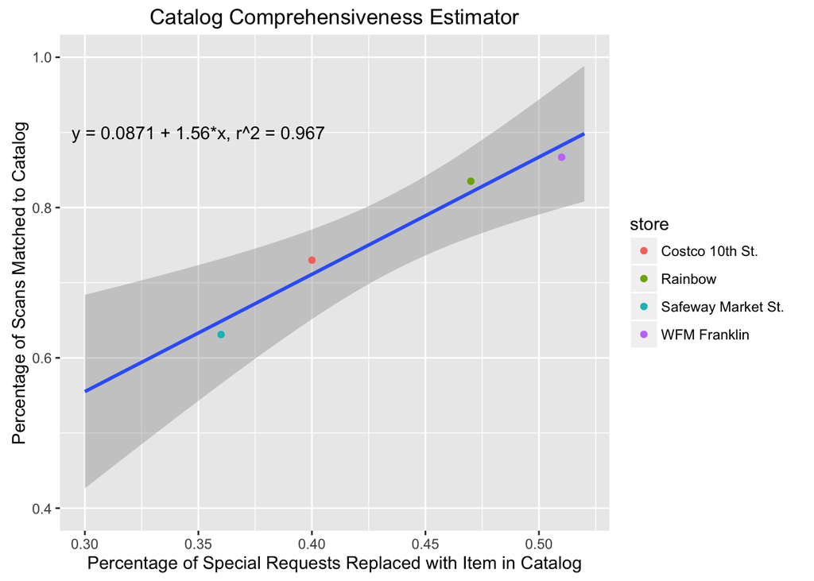

```r
ggplot(comp,aes(x=sr_replaced,y=match_rate,label=store))+ geom_smooth(method = 'lm',fullrange=TRUE) + annotate("text", label = "y = 0.0871 + 1.56*x, r^2 = 0.967",x=0.35,y=0.9) +ggtitle("Catalog Comprehensiveness Estimator") + geom_point(aes(colour = store)) + ylim(0.4,1) + xlim(0.3,0.52) + labs(x="Percentage of Special Requests Replaced with Item in Catalog",y="Percentage of Scans Matched to Catalog")
```

In conclusion, the percentage of special requests replaced by items in our catalog can be used as a strong indicator of catalog comprehensiveness. However, we have to be careful about the strength this correlation as it is based on only 4 data points.